# Regressions In Markdown

Lib

04/08/2020

```r
#Set seed for random number generation
set.seed(42)
knitr::opts_chunk$set(cache.extra = knitr::rand_seed)
```

# Research Questions

As readers do we predict upcoming information before it is encountered in order to better understand the unfolding discourse?

If prediction is not utilized do we rely on more on basic integration to understand an unfolding discourse context?

Do individual differences contribute to our ability to predict and/or integrate upcoming information? How do these contribute?

# Region 4: The question

Let’s have a look at various models for our critical region of interest, the question.

```r
#Let's have a look at region 4

#set condition as a factor
all_data_join$cond <- as.factor(all_data_join$cond)
```

## Eye-tracking only model

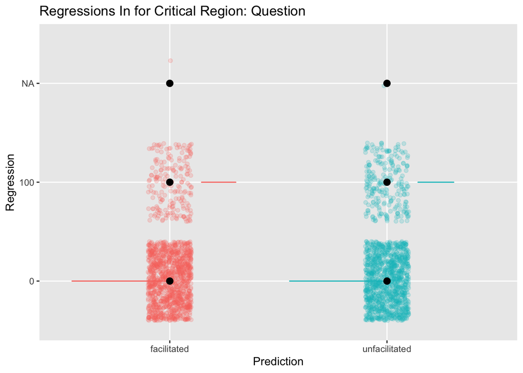

```r
#Let's have a look at region 4

all_data_join$R4[all_data_join$R4 == 1] <-"100"
all_data_join$R4 <- as.factor(all_data_join$R4)

#Visualisation
all_data_join %>%
  ggplot(aes(x = cond, y = R4, colour = cond)) + ggtitle("Regressions In for Critical Region: Question") +
  labs(y = "Regression", x = "Prediction") +
  geom_violin() +
  geom_jitter(alpha = .2, width = .1) +
  stat_summary(fun.data = "mean_cl_boot", colour = "black") +
  guides(colour = FALSE)
```

```r
# Model assuming normality of residuals maximal structure
#model.nullR4 <- lmer(R4 ~ (1 + cond | subj) + (1 + cond | item), all_data_join)
modelR4 <- glmer(R4 ~ cond + (1 | subj) + (1 | item), all_data_join, family = "binomial")
summary(modelR4)
```

```
## Generalized linear mixed model fit by maximum likelihood (Laplace
##   Approximation) [glmerMod]
##  Family: binomial  ( logit )
## Formula: R4 ~ cond + (1 | subj) + (1 | item)
##    Data: all_data_join
##
##      AIC      BIC   logLik deviance df.resid
##   2254.0   2277.6  -1123.0   2246.0     2682
##
## Scaled residuals:
##     Min      1Q  Median      3Q     Max
## -1.0939 -0.4278 -0.3436 -0.2692  4.4316
##
## Random effects:
##  Groups Name        Variance Std.Dev.
##  subj   (Intercept) 0.63802  0.7988
##  item   (Intercept) 0.08245  0.2871
## Number of obs: 2686, groups:  subj, 84; item, 32
##
## Fixed effects:
##                   Estimate Std. Error z value Pr(>|z|)
## (Intercept)        -2.0216     0.1332 -15.177   <2e-16 ***
## condunfacilitated   0.2791     0.1092   2.556   0.0106 *
## ---
## Signif. codes:  0 '***' 0.001 '**' 0.01 '*' 0.05 '.' 0.1 ' ' 1
##
## Correlation of Fixed Effects:
##             (Intr)
## condnfclttd -0.451
```

```r
#anova(modelR4, model.nullR4)

#All the data for this model looks pretty normal.
check_model(modelR4)
```

```
## Not enough model terms in the conditional part of the model to check for multicollinearity.
```

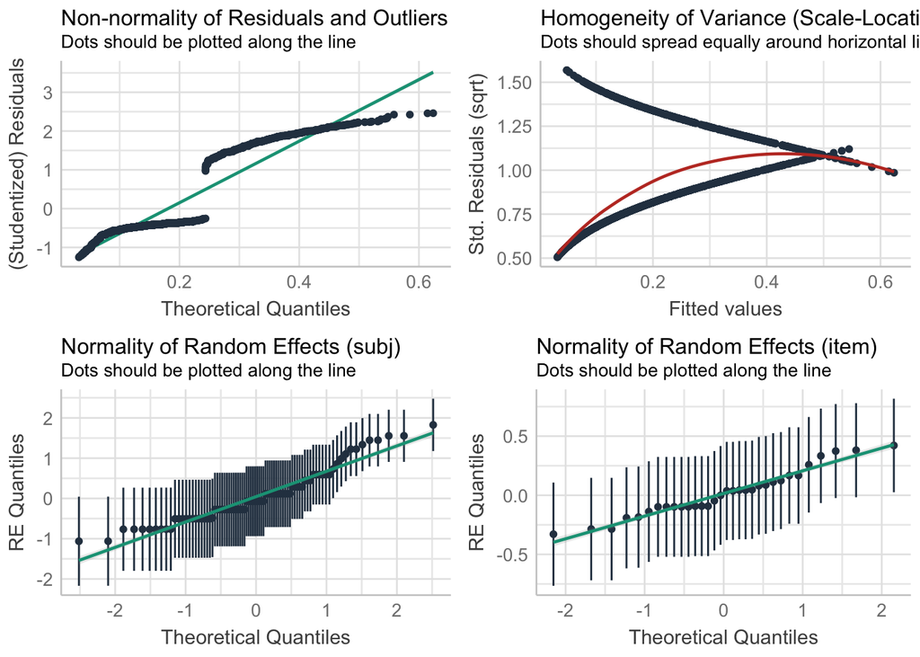

```r
#qqnorm(residuals(modelR4))
#qqline(residuals(modelR4))
#descdist(all_data_join$R4)
```

## Individual differences as controlling factors

```r
#Let's include some co-variates! Region 4

#Step 1: Scale the ID measures...
all_data_join$SRS_total_score_t <- scale(all_data_join$SRS_total_score_t)
all_data_join$EQ <- scale(all_data_join$EQ)
all_data_join$Total_reading_cluster <- scale(all_data_join$Total_reading_cluster)
all_data_join$Total_RAN <- scale(all_data_join$Total_RAN)
all_data_join$"WI _RPI" <- scale(all_data_join$"WI _RPI")
```

```r
# Model including covariates
model_alldatacov_R4 <- glmer(R4 ~ SRS_total_score_t + EQ + Total_reading_cluster + Total_RAN + cond + (1 | subj) +  (1 | item) , data = all_data_join, family = "binomial")

#model_alldatacov_R4_null <- lmer(R4 ~ SRS_total_score_t + EQ + Total_reading_cluster + #Total_RAN +
#                               (1 + cond | subj) +  (1 + cond | item) , data = #all_data_join, , family = "binomial")

summary(model_alldatacov_R4)
```

```
## Generalized linear mixed model fit by maximum likelihood (Laplace
##   Approximation) [glmerMod]
##  Family: binomial  ( logit )
## Formula: R4 ~ SRS_total_score_t + EQ + Total_reading_cluster + Total_RAN +
##     cond + (1 | subj) + (1 | item)
##    Data: all_data_join
##
##      AIC      BIC   logLik deviance df.resid
##   2211.4   2258.4  -1097.7   2195.4     2646
##
## Scaled residuals:
##     Min      1Q  Median      3Q     Max
## -1.0342 -0.4268 -0.3412 -0.2640  4.7525
##
## Random effects:
##  Groups Name        Variance Std.Dev.
##  subj   (Intercept) 0.53357  0.7305
##  item   (Intercept) 0.07568  0.2751
## Number of obs: 2654, groups:  subj, 83; item, 32
##
## Fixed effects:
##                       Estimate Std. Error z value Pr(>|z|)
## (Intercept)           -2.04335    0.12885 -15.859  < 2e-16 ***
## SRS_total_score_t      0.10228    0.12546   0.815  0.41492
## EQ                    -0.06997    0.12609  -0.555  0.57893
## Total_reading_cluster  0.30855    0.10366   2.977  0.00292 **
## Total_RAN              0.10874    0.10291   1.057  0.29067
## condunfacilitated      0.29013    0.11042   2.627  0.00860 **
## ---
## Signif. codes:  0 '***' 0.001 '**' 0.01 '*' 0.05 '.' 0.1 ' ' 1
##
## Correlation of Fixed Effects:
##             (Intr) SRS___ EQ     Ttl_r_ Tt_RAN
## SRS_ttl_sc_ -0.017
## EQ           0.004  0.633
## Ttl_rdng_cl -0.068  0.019  0.018
## Total_RAN   -0.024 -0.063 -0.074  0.253
## condnfclttd -0.473  0.002 -0.001  0.007  0.003
```

So Total_reading_cluster and our condition are significant.

If we drop the Total_reading_cluster the effect of condition is still there (see below) - suggesting to me that the effect of Total_reading_cluster is separate from the effect of condition.

```r
model_alldatacov_R4_noWRMT <- glmer(R4 ~ SRS_total_score_t + EQ + Total_RAN + cond + (1 | subj) +  (1 | item) , data = all_data_join, family = "binomial")
summary(model_alldatacov_R4_noWRMT)
```

```
## Generalized linear mixed model fit by maximum likelihood (Laplace
##   Approximation) [glmerMod]
##  Family: binomial  ( logit )
## Formula: R4 ~ SRS_total_score_t + EQ + Total_RAN + cond + (1 | subj) +
##     (1 | item)
##    Data: all_data_join
##
##      AIC      BIC   logLik deviance df.resid
##   2217.9   2259.0  -1101.9   2203.9     2647
##
## Scaled residuals:
##     Min      1Q  Median      3Q     Max
## -1.0587 -0.4247 -0.3428 -0.2694  4.5555
##
## Random effects:
##  Groups Name        Variance Std.Dev.
##  subj   (Intercept) 0.60969  0.7808
##  item   (Intercept) 0.07575  0.2752
## Number of obs: 2654, groups:  subj, 83; item, 32
##
## Fixed effects:
##                   Estimate Std. Error z value Pr(>|z|)
## (Intercept)       -2.03784    0.13212 -15.424  < 2e-16 ***
## SRS_total_score_t  0.09618    0.13129   0.733  0.46382
## EQ                -0.07498    0.13206  -0.568  0.57019
## Total_RAN          0.03188    0.10404   0.306  0.75925
## condunfacilitated  0.29012    0.11028   2.631  0.00852 **
## ---
## Signif. codes:  0 '***' 0.001 '**' 0.01 '*' 0.05 '.' 0.1 ' ' 1
##
## Correlation of Fixed Effects:
##             (Intr) SRS___ EQ     Tt_RAN
## SRS_ttl_sc_ -0.014
## EQ           0.006  0.631
## Total_RAN   -0.007 -0.068 -0.081
## condnfclttd -0.461  0.002 -0.001  0.001
```

Does Total_reading cluster interact with our condition? No (see below.)

```r
model_alldatacov_R4_WRMT_int <- glmer(R4 ~ SRS_total_score_t + EQ + Total_reading_cluster + Total_RAN + cond + cond:Total_reading_cluster+ (1 | subj) +  (1 | item) , data = all_data_join, family = "binomial")
summary(model_alldatacov_R4_WRMT_int)
```

```
## Generalized linear mixed model fit by maximum likelihood (Laplace
##   Approximation) [glmerMod]
##  Family: binomial  ( logit )
## Formula: R4 ~ SRS_total_score_t + EQ + Total_reading_cluster + Total_RAN +
##     cond + cond:Total_reading_cluster + (1 | subj) + (1 | item)
##    Data: all_data_join
##
##      AIC      BIC   logLik deviance df.resid
##   2213.1   2266.1  -1097.6   2195.1     2645
##
## Scaled residuals:
##     Min      1Q  Median      3Q     Max
## -1.0365 -0.4271 -0.3428 -0.2636  4.9150
##
## Random effects:
##  Groups Name        Variance Std.Dev.
##  subj   (Intercept) 0.53367  0.7305
##  item   (Intercept) 0.07571  0.2751
## Number of obs: 2654, groups:  subj, 83; item, 32
##
## Fixed effects:
##                                         Estimate Std. Error z value Pr(>|z|)
## (Intercept)                             -2.04969    0.12960 -15.815  < 2e-16
## SRS_total_score_t                        0.10226    0.12547   0.815  0.41507
## EQ                                      -0.06979    0.12610  -0.553  0.57994
## Total_reading_cluster                    0.34150    0.12160   2.808  0.00498
## Total_RAN                                0.10871    0.10291   1.056  0.29081
## condunfacilitated                        0.30064    0.11218   2.680  0.00736
## Total_reading_cluster:condunfacilitated -0.05973    0.11457  -0.521  0.60209
##
## (Intercept)                             ***
## SRS_total_score_t
## EQ
## Total_reading_cluster                   **
## Total_RAN
## condunfacilitated                       **
## Total_reading_cluster:condunfacilitated
## ---
## Signif. codes:  0 '***' 0.001 '**' 0.01 '*' 0.05 '.' 0.1 ' ' 1
##
## Correlation of Fixed Effects:
##             (Intr) SRS___ EQ     Ttl_r_ Tt_RAN cndnfc
## SRS_ttl_sc_ -0.017
## EQ           0.003  0.633
## Ttl_rdng_cl -0.112  0.016  0.016
## Total_RAN   -0.024 -0.063 -0.074  0.217
## condnfclttd -0.482  0.002  0.000  0.106  0.003
## Ttl_rdng_c:  0.096  0.001 -0.002 -0.522 -0.001 -0.174
```

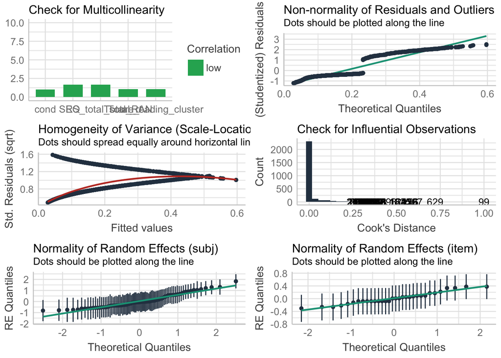

```r
#anova(model_alldatacov_R4_null, model_alldatacov_R4)
check_model(model_alldatacov_R4)
```

```r
ranef(model_alldatacov_R4)
```

```
## $subj
##     (Intercept)
## 1   1.033216872
## 10 -0.632826162
## 11  0.717903953
## 12  0.644012440
## 13  0.398284307
## 14 -0.752375118
## 15  0.055348656
## 16 -0.523038795
## 17  0.664417477
## 18 -0.168802472
## 19 -0.823071526
## 2   0.504151768
## 20  0.098584862
```

[output cut: 107 more lines]

# summary of Results for region 4, the question.

Regardless of whether the individual predictors are present/absent, the effect of our condition is pretty much the same - suggesting to me that the variance explained by our experimental manipulation doesn’t overlap with the variance explained by our individual difference measures.

# Correlations

```r
library(Hmisc)
#Measuring Correlations
EQscore <- all_data_join %>% group_by(subj) %>% summarise(mean = mean(EQ)) %>% pull(mean)
SRS2 <- all_data_join %>% group_by(subj) %>% summarise(mean = mean(SRS_total_score_t)) %>% pull(mean)
WRMT <- all_data_join %>% group_by(subj) %>% summarise(mean = mean(Total_reading_cluster)) %>% pull(mean)
RAN <- all_data_join %>% group_by(subj) %>% summarise(mean = mean(Total_RAN)) %>% pull(mean)
rcorr(EQscore, SRS2)
```

```
##       x     y
## x  1.00 -0.63
## y -0.63  1.00
##
## n= 84
##
##
## P
##   x  y
## x     0
## y  0
```

```r
rcorr(EQscore, WRMT)
```

```
##   x y
## x 1 0
## y 0 1
##
## n= 84
##
##
## P
##   x      y
## x        0.9673
## y 0.9673
```

```r
rcorr(EQscore, RAN)
```

```
##      x    y
## x 1.00 0.02
## y 0.02 1.00
##
## n
##    x  y
## x 84 83
## y 83 83
##
## P
##   x      y
## x        0.8428
## y 0.8428
```

```r
rcorr(SRS2, WRMT)
```

```
##       x     y
## x  1.00 -0.02
## y -0.02  1.00
##
## n= 84
##
##
## P
##   x      y
## x        0.8494
## y 0.8494
```

```r
rcorr(SRS2, RAN)
```

```
##      x    y
## x 1.00 0.03
## y 0.03 1.00
##
## n
##    x  y
## x 84 83
## y 83 83
##
## P
##   x      y
## x        0.7566
## y 0.7566
```

```r
rcorr(WRMT, RAN)
```

```
##       x     y
## x  1.00 -0.26
## y -0.26  1.00
##
## n
##    x  y
## x 84 83
## y 83 83
##
## P
##   x      y
## x        0.0159
## y 0.0159
```

# Region 5: The reply

Let’s have a look at various models for our post-critical region of interest, the reply.

## Eye-tracking only model

```r
#set condition as a factor, convert 1 to 100 and remove NAs
all_data_join$cond <- as.factor(all_data_join$cond)
all_data_join$R5[all_data_join$R5 == 1] <-"100"
all_data_join$R5 <- as.factor(all_data_join$R5)
```

## Eye-tracking only model

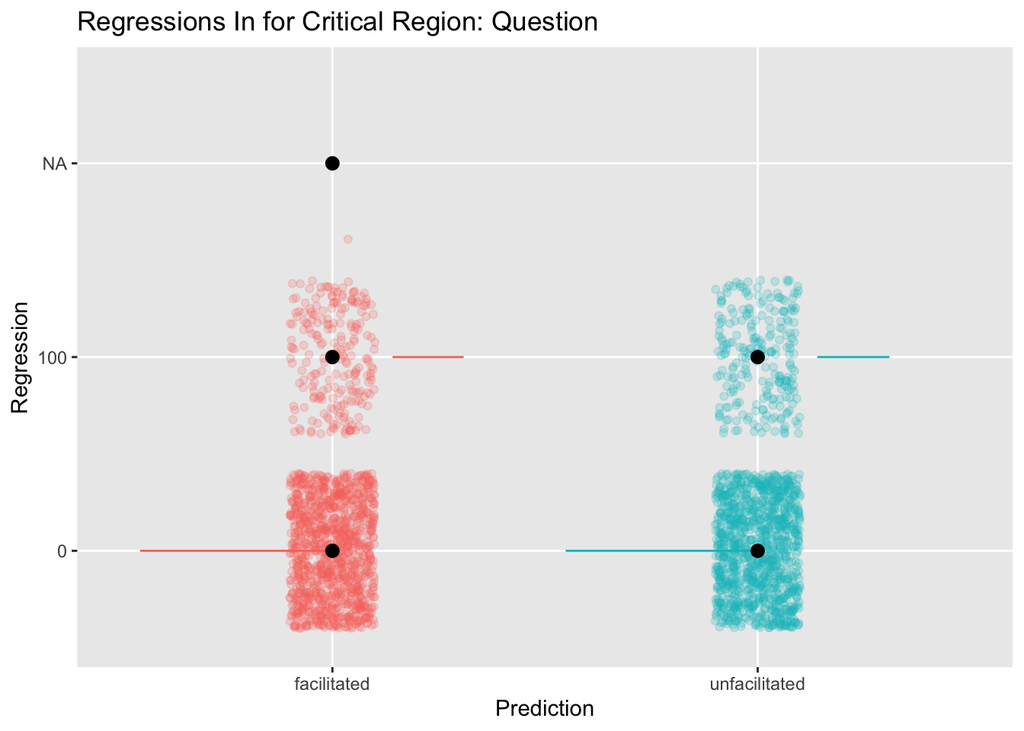

```r
#Let's have a look at region 4

#Visualisation
all_data_join %>%
  ggplot(aes(x = cond, y = R5, colour = cond)) + ggtitle("Regressions In for Critical Region: Question") +
  labs(y = "Regression", x = "Prediction") +
  geom_violin() +
  geom_jitter(alpha = .2, width = .1) +
  stat_summary(fun.data = "mean_cl_boot", colour = "black") +
  guides(colour = FALSE)
```

```r
# Model assuming normality of residuals maximal structure
#model.nullR5 <- lmer(R5 ~ (1 | subj) + (1 | item), all_data_join)
modelR5 <- glmer(R5 ~ cond + (1 | subj) + (1 | item), data = all_data_join, family = "binomial")
summary(modelR5)
```

```
## Generalized linear mixed model fit by maximum likelihood (Laplace
##   Approximation) [glmerMod]
##  Family: binomial  ( logit )
## Formula: R5 ~ cond + (1 | subj) + (1 | item)
##    Data: all_data_join
##
##      AIC      BIC   logLik deviance df.resid
##   2389.2   2412.7  -1190.6   2381.2     2683
##
## Scaled residuals:
##     Min      1Q  Median      3Q     Max
## -1.1002 -0.4690 -0.3761 -0.2769  4.2617
##
## Random effects:
##  Groups Name        Variance Std.Dev.
##  subj   (Intercept) 0.53000  0.7280
##  item   (Intercept) 0.08842  0.2974
## Number of obs: 2687, groups:  subj, 84; item, 32
##
## Fixed effects:
##                   Estimate Std. Error z value Pr(>|z|)
## (Intercept)       -1.79670    0.12488 -14.387   <2e-16 ***
## condunfacilitated  0.08814    0.10527   0.837    0.402
## ---
## Signif. codes:  0 '***' 0.001 '**' 0.01 '*' 0.05 '.' 0.1 ' ' 1
##
## Correlation of Fixed Effects:
##             (Intr)
## condnfclttd -0.432
```

```r
#anova(modelR5, model.nullR5)

#All the data for this model looks pretty normal.
check_model(modelR5)
```

```
## Not enough model terms in the conditional part of the model to check for multicollinearity.
```

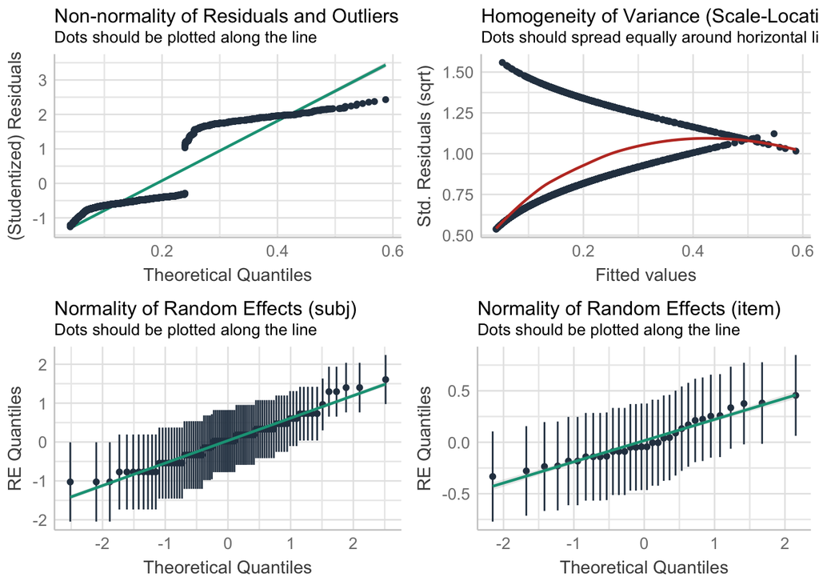

```r
#qqnorm(residuals(modelR5))
#qqline(residuals(modelR5))
#descdist(all_data_join$R5)
```

## Individual differences as controlling factors

```r
#Let's include some co-variates! Region 4

#Step 1: Scale the ID measures...
all_data_join$SRS_total_score_t <- scale(all_data_join$SRS_total_score_t)
all_data_join$EQ <- scale(all_data_join$EQ)
all_data_join$Total_reading_cluster <- scale(all_data_join$Total_reading_cluster)
all_data_join$Total_RAN <- scale(all_data_join$Total_RAN)
all_data_join$"WI _RPI" <- scale(all_data_join$"WI _RPI")
```

```r
# Model including covariates
model_alldatacov_R5 <- glmer(R5 ~ SRS_total_score_t + EQ + Total_reading_cluster + Total_RAN + cond + (1 | subj) +  (1 | item) , data = all_data_join, family = "binomial")

#model_alldatacov_R5_null <- lmer(R5 ~ SRS_total_score_t + EQ + Total_reading_cluster + #Total_RAN +
#                               (1 + cond | subj) +  (1 + cond | item) , data = #all_data_join, REML = TRUE)

summary(model_alldatacov_R5)
```

```
## Generalized linear mixed model fit by maximum likelihood (Laplace
##   Approximation) [glmerMod]
##  Family: binomial  ( logit )
## Formula: R5 ~ SRS_total_score_t + EQ + Total_reading_cluster + Total_RAN +
##     cond + (1 | subj) + (1 | item)
##    Data: all_data_join
##
##      AIC      BIC   logLik deviance df.resid
##   2348.8   2395.9  -1166.4   2332.8     2647
##
## Scaled residuals:
##     Min      1Q  Median      3Q     Max
## -1.1202 -0.4632 -0.3727 -0.2766  4.0641
##
## Random effects:
##  Groups Name        Variance Std.Dev.
##  subj   (Intercept) 0.46382  0.681
##  item   (Intercept) 0.09119  0.302
## Number of obs: 2655, groups:  subj, 83; item, 32
##
## Fixed effects:
##                       Estimate Std. Error z value Pr(>|z|)
## (Intercept)           -1.81526    0.12302 -14.756   <2e-16 ***
## SRS_total_score_t     -0.01711    0.11845  -0.144    0.885
## EQ                    -0.13724    0.11966  -1.147    0.251
## Total_reading_cluster  0.23089    0.09672   2.387    0.017 *
## Total_RAN              0.12368    0.09695   1.276    0.202
## condunfacilitated      0.09668    0.10628   0.910    0.363
## ---
## Signif. codes:  0 '***' 0.001 '**' 0.01 '*' 0.05 '.' 0.1 ' ' 1
##
## Correlation of Fixed Effects:
##             (Intr) SRS___ EQ     Ttl_r_ Tt_RAN
## SRS_ttl_sc_  0.007
## EQ           0.023  0.632
## Ttl_rdng_cl -0.047 -0.003  0.000
## Total_RAN   -0.031 -0.071 -0.085  0.252
## condnfclttd -0.444  0.000 -0.001  0.002  0.001
```

So only WRMT is significant.

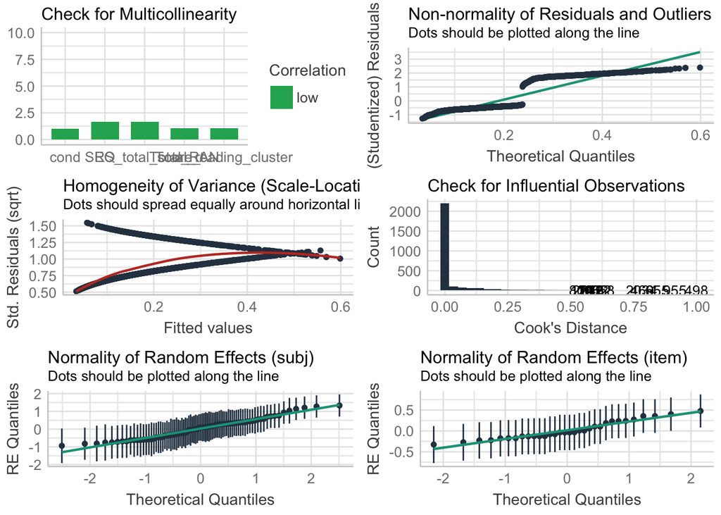

```r
#anova(model_alldatacov_R5_null, model_alldatacov_R5)
check_model(model_alldatacov_R5)
```

```r
ranef(model_alldatacov_R5)
```

```
## $subj
##     (Intercept)
## 1   1.332632149
## 10 -0.590158026
## 11  0.336238965
## 12  0.113811847
## 13  0.245924322
## 14 -0.323090569
## 15  0.579897410
## 16  0.276359613
## 17  0.322091996
## 18 -0.354075292
## 19 -0.619082377
## 2  -0.020207947
## 20 -0.366951092
```

[output cut: 107 more lines]